```python
from adpil import *
from ia636 import *
```

# Ex03e4_2014

O objetivo da lista de exercícios das aulas 3 e 4 é consolidar os conceitos de tranformação de níveis de cinza usando funções de transferência, consolidar os conceitos de equalização e normalização de histogramas. Não será pedido que se implemente uma função para aplicar uma LUT, mas o aluno deveria refletir como deveria ser a implementação eficiente de tal função antes de fazer o primeiro exercício.

A partir desta lista, usaremos um novo conjunto de imagens de testes (que já se encontra no link de imagens que serão usadas no curso). Ele pode ser visto em http://parati.dca.fee.unicamp.br/adesso/wiki/app/hirata/view/ e pode ser carregado com o comando adread. Por exemplo: `adread('hirata/imagesBio/heart.png')`.

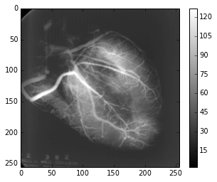

```python
pylab.rcParams['figure.figsize'] = (5, 4)

cor = adread('hirata/imagesBio/heart.png')
gray()
imshow(cor)
colorbar();
```

# Exercício 1

1- Estude a documentação da função iaapplylut e explique o funcionamento do código. Este exercício é essencialmente de Python (e de quebra Matlab), mas é muito útil para aprender a trabalhar eficientemente com arrays e matrizes.

## Resposta

O objetivo da função iaapplylut é encontrar uma valor correspondente numa LUT para cada um da imagem. Isso é feito de forma bem eficiente no código python das linhas abaixo:

[output not shown]

Resumo da "mágica" que acontece:

1. A função `iaapplylut` usa o método `revel()` para transformar a imagem em um array 1D (equivalente à um `flatten`).
2. Para cada valor desse array flat, a função recupera um valor correspondente na LUT. Isso é feito de forma eficiente com a chamada `map()` e uma função interna `lut_map()`.
3. Depois que cada valor foi transformado, é feito um `reshape()` para que o array 1D volte a dimensão original.

Links pesquisados:

- http://www.dca.fee.unicamp.br/ia636/ia636/iaapplylut.html
- http://adessowiki.fee.unicamp.br/adesso/wiki/ia636/iaapplylut/view/

# Exercício 2

2- Crie uma LUT que inverta os níveis de cinza de uma imagem, isto é, o nível de cinza 255 será mapeado em 0; o nível 254 será mapeado em 1; e assim por diante, até o nível 0 ser mapeado em 255. Carregue uma imagem e aplique a LUT com a função iaapplylut. Repita o procedimento acima com mais 9 outras imagens diferentes.

[figure not shown]

```python
pylab.rcParams['figure.figsize'] = (7, 22)
gray()
def negate(img):
    it = 255 - arange(256)
    return iaapplylut(img, it)

imgs = ["hedgebw.png", "mare.png", "leopard.png", "7.1.06.png", "mesa.png", "4.2.06.png", "5.1.14.png", "indor3.png", "mapasp.png", "test1.png"]

for i, f in enumerate(imgs):
    subplot(len(imgs)/2+1, 2, i+1)
    img = adread('../images/images256/' + f)
    imshow(negate(img))
```

# Exercício 3

3- Crie uma LUT em forma de degrau, isto é, uma LUT que mapeie todos os valores abaixo de 120 para 0 e os valores maiores para 255. Carregue uma imagem e aplique a LUT com a função iaapplylut. Repita o procedimento acima com mais 9 outras imagens diferentes.

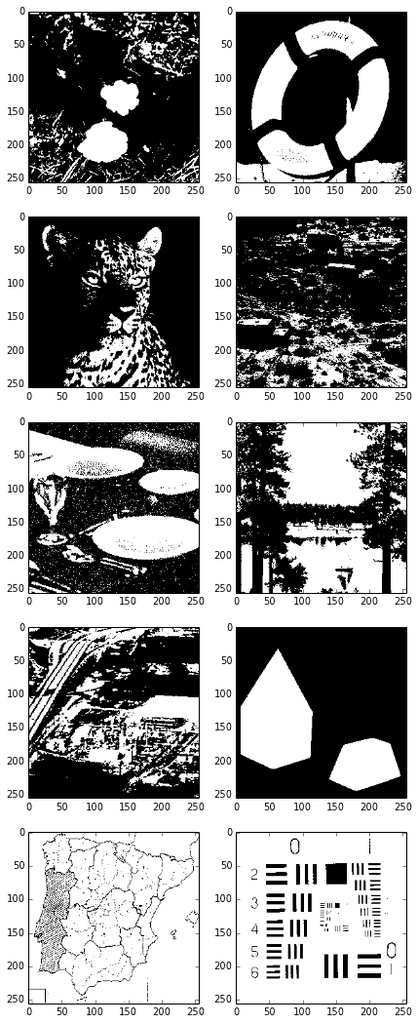

```python
pylab.rcParams['figure.figsize'] = (7, 22)

def lut_degrau(img):
    lut = arange(256)
    lut[:120] = 0
    lut[120:] = 255

    return iaapplylut(img, lut)

for i, f in enumerate(imgs):
    img = adread('hirata/images256/' + f)
    subplot(len(imgs)/2+1, 2, i+1)
    imshow(lut_degrau(img))
```

# Exercício 4

4- Crie uma LUT em forma de escada de cinco degraus de mesmo tamanho, isto é, uma LUT que mapeie os valores de 0..50 em 0, 51..101 em 50, 102..152 em 100, 153..203 em 150 e 204..255 em 200. Carregue uma imagem e aplique a LUT com a função iaapplylut. Repita o procedimento acima com mais 9 outras imagens diferentes.

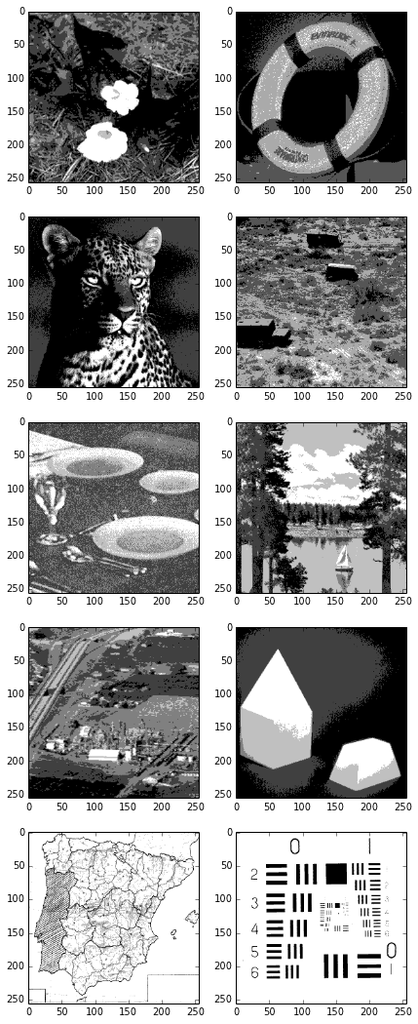

```python
pylab.rcParams['figure.figsize'] = (7, 22)

def lut_escada(img):
    lut = arange(256)
    for i in range(5):
        lut[i*51:] = i * 50
    return iaapplylut(img, lut)

for i, f in enumerate(imgs):
    img = adread('hirata/images256/' + f)
    subplot(len(imgs)/2+1, 2, i+1)
    imshow(lut_escada(img))
```

# Exercício 5

Escolha um conjunto de cinco imagens que possuam características semelhantes, apresente as imagens e os histogramas dessas imagens. Crie uma LUT (resultado de uma função analítica para simplificar) que realce visualmente alguns aspectos que você considera importantes na imagem. Apresente a LUT em forma de um gráfico. Aplique a LUT em todas as imagens escolhidas e relate todo o experimento em palavras. Não esqueça de escrever sua função analítica em latex. Apresente também o histograma da imagem após a aplicação da LUT e compare com o histograma antes da aplicação da LUT. O resultado na forma do histograma era o esperado? Note que faz parte do exercício cuidar para que os limites da quantização não ultrapassem os limites válidos da imagem de entrada.

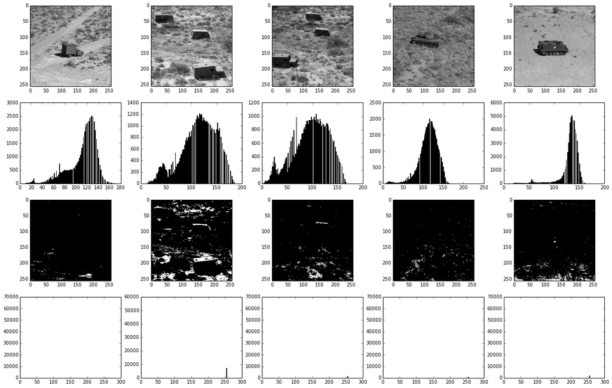

```python
pylab.rcParams['figure.figsize'] = (22, 14)

def lut_ex5():
    lut = zeros(256, integer)
    lut[152:204] = 255
    return lut

imgs = ["7.1.01.png", "7.1.05.png", "7.1.06.png", "7.1.07.png", "7.1.08.png"]
for i, file in enumerate(imgs):
    img = adread('hirata/images256/' + file)
    gray()

    # imagem original
    subplot(4, 5, i+1)
    imshow(img)

    # histograma original
    subplot(4, 5, 6+i)
    hist(img.flatten(), bins=255)

    # imagem com LUT
    subplot(4, 5, 11+i)
    img_lut = iaapplylut(img, lut_ex5())
    imshow(img_lut)

    # histograma com LUT
    subplot(4, 5, 16+i)
    hist(img_lut.flatten(), bins=255)
```

### Explicação do experimento (tentativa 1)

$$ LUT(x)=\begin{cases} 255 & for\quad 152\leq x\leq 204 \\ 0 & otherwise \end{cases} $$

Plotando a função LUT, obtemos o seguinte gráfico:

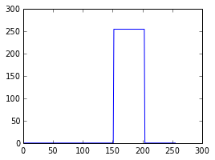

```python
pylab.rcParams['figure.figsize'] = (4,3)
plot(lut_ex5());
```

# Exercício 6

6- Escolha um conjunto de sete imagens que você considere que necessitem de equalização de histograma. Apresente a imagem e o histograma dessas imagens. Estude a função cumsum e faça uma comparação em termos de eficiência de tempo com a que você implementou no exercício passado. Calcule o histograma acumulativo das frequências relativas dos níveis de cinza e apresente o gráfico desse histograma. Use esse histograma como LUT (não se esqueça de multiplicar pelo máximo valor possível do domínio da saída). Apresente a imagem resultante, o novo histograma e o novo histograma acumulativo da imagem.

Tarefas:

- escolhar imagens que necessitem de equalização de histograma
- apresentar a imagem e o histograma
- comparação entre a cummsum e a forma naive
- histograma acumulativo das frequências relativas e mostrar plot
- mostrar imagem com histograma relativo como LUT
- mostrar histograma acumulativo da imagem

#### Função discreta do histograma:

$h\left(r_k\right)=n_k$, where $r_k$ is the $k$th intensity value and $n_k$ is the number of pixels in the image with intensity $r_k$.

```python
pylab.rcParams['figure.figsize'] = (30.0, 30.0)

imgs = ["carnev.png", "leopard.png", "nat6.png", "venice.png", "4.1.02.png", "nat5.png", "foto.png"]

def map_value(value, start1, stop1, start2, stop2):
  return start2 + (stop2 - start2) * ((value - start1) / (stop1 - start1))

def histograma(img):
    histo = zeros(256)
    m, n = shape(img)
    for i in range(m):
        for j in range(n):
            histo[img[i][j]] += 1

    return histo / (m*n)

def histograma_acc(img):
    return cumsum(histograma(img))

for i, file in enumerate(imgs):
    img = adread('hirata/images256/' + file)
    subplot(len(imgs), 5, i*5+1); axis('off');
    imshow(img)
    colorbar()

    subplot(len(imgs), 5, i*5+2);
    plot(histograma(img))

    subplot(len(imgs), 5, i*5+3);
    plot(histograma_acc(img))

    subplot(len(imgs), 5, i*5+4);
    img_lut = iaapplylut(img, histograma_acc(img))
    imshow(img_lut)
    colorbar()

    subplot(len(imgs), 5, i*5+5);
    hist(img_lut, acc=True, bins=255)
```

[output not shown]

7- Repita o exercício anterior para o caso da normalização de histogramas.